# Ejercicio Final - GLM

Javier Herráez Albarrán

# Cancelaciones en reservas de hotel

En este ejercicio contamos con un dataset que almacena reservas de hotel con una serie de características y nuestro propósito será predecir si un cliente cancelará su reserva o no.

El dataset está disponible en: https://www.kaggle.com/jessemostipak/hotel-booking-demand

Para lograr nuestro objetivo contamos con la siguiente información:

- **hotel**: Hotel (H1 = Resort Hotel or H2 = City Hotel)
- **is_canceled (TARGET)**: Value indicating if the booking was canceled (1) or not (0)
- **lead_time**: Number of days that elapsed between the entering date of the booking into the PMS and the arrival date
- **arrival_date_year**: Year of arrival date
- **arrival_date_month**: Month of arrival date
- **arrival_date_week_number**: Week number of year for arrival date
- **arrival_date_day_of_month**: Day of arrival date
- **stays_in_weekend_nights**: Number of weekend nights (Saturday or Sunday) the guest stayed or booked to stay at the hotel
- **stays_in_week_nights**: Number of week nights (Monday to Friday) the guest stayed or booked to stay at the hotel
- **adults**: Number of adults
- **children**: Number of children
- **babies**: Number of babies
- **meal**: Type of meal booked. Categories are presented in standard hospitality meal packages: Undefined/SC – no meal package; BB – Bed & Breakfast; HB – Half board (breakfast and one other meal – usually dinner); FB – Full board (breakfast, lunch and dinner)
- **country**: Country of origin. Categories are represented in the ISO 3155–3:2013 formatCountry of origin. Categories are represented in the ISO 3155–3:2013 format
- **market_segment**: Market segment designation. In categories, the term “TA” means “Travel Agents” and “TO” means “Tour Operators”
- **distribution_channel**: Booking distribution channel. The term “TA” means “Travel Agents” and “TO” means “Tour Operators”
- **is_repeated_guest**: Value indicating if the booking name was from a repeated guest (1) or not (0)
- **previous_cancellations**: Number of previous bookings that were cancelled by the customer prior to the current booking
- **previous_bookings_not_canceled**: Number of previous bookings not cancelled by the customer prior to the current booking
- **reserved_room_type**: Code of room type reserved. Code is presented instead of designation for anonymity reasons.
- **assigned_room_type**: Code for the type of room assigned to the booking. Sometimes the assigned room type differs from the reserved room type due to hotel operation reasons (e.g. overbooking) or by customer request. Code is presented instead of designation for anonymity reasons.
- **booking_changes**: Number of changes/amendments made to the booking from the moment the booking was entered on the PMS until the moment of check-in or cancellation
- **deposit_type**: Indication on if the customer made a deposit to guarantee the booking. This variable can assume three categories: No Deposit – no deposit was made; Non Refund – a deposit was made in the value of the total stay cost; Refundable – a deposit was made with a value under the total cost of stay.
- **agent**: ID of the travel agency that made the booking
- **company**: ID of the company/entity that made the booking or responsible for paying the booking. ID is presented instead of designation for anonymity reasons
- **days_in_waiting_list**: Number of days the booking was in the waiting list before it was confirmed to the customer
- **customer_type**: Type of booking, assuming one of four categories: Contract - when the booking has an allotment or other type of contract associated to it; Group – when the booking is associated to a group; Transient – when the booking is not part of a group or contract, and is not associated to other transient booking; Transient-party – when the booking is transient, but is associated to at least other transient booking
- **adr**: Average Daily Rate as defined by dividing the sum of all lodging transactions by the total number of staying nights
- **required_car_parking_spaces**: Number of car parking spaces required by the customer
- **total_of_special_requests**: Number of special requests made by the customer (e.g. twin bed or high floor)
- **reservation_status**: Reservation last status, assuming one of three categories: Canceled – booking was canceled by the customer; Check-Out – customer has checked in but already departed; No-Show – customer did not check-in and did inform the hotel of the reason why
- **reservation_status_date**: Date at which the last status was set. This variable can be used in conjunction with the ReservationStatus to understand when was the booking canceled or when did the customer checked-out of the hotel

## Data & Exploratory

Lo primero de todo será cargar nuestro dataset y hacer un resumen de nuestras variables:

```r
rm(list=ls())

library(tidyverse)
library(Hmisc)
library(corrplot)
library(effects)
library(caret)

# setwd("C:/Users/jherraez/Documents/masterAFI/10. Regresion Avanzada/javier_herraez_albarran_regresion_avanzada/")

set.seed(1404)

booking <- read.csv("hotel_bookings.csv", header = TRUE)
```

```r
str(booking)
```

```
## 'data.frame':    119390 obs. of  32 variables:
##  $ hotel                         : chr  "Resort Hotel" "Resort Hotel" "Resort Hotel" "Resort Hotel" ...
##  $ is_canceled                   : int  0 0 0 0 0 0 0 0 1 1 ...
##  $ lead_time                     : int  342 737 7 13 14 14 0 9 85 75 ...
##  $ arrival_date_year             : int  2015 2015 2015 2015 2015 2015 2015 2015 2015 2015 ...
##  $ arrival_date_month            : chr  "July" "July" "July" "July" ...
##  $ arrival_date_week_number      : int  27 27 27 27 27 27 27 27 27 27 ...
##  $ arrival_date_day_of_month     : int  1 1 1 1 1 1 1 1 1 1 ...
##  $ stays_in_weekend_nights       : int  0 0 0 0 0 0 0 0 0 0 ...
##  $ stays_in_week_nights          : int  0 0 1 1 2 2 2 2 3 3 ...
##  $ adults                        : int  2 2 1 1 2 2 2 2 2 2 ...
##  $ children                      : int  0 0 0 0 0 0 0 0 0 0 ...
##  $ babies                        : int  0 0 0 0 0 0 0 0 0 0 ...
##  $ meal                          : chr  "BB" "BB" "BB" "BB" ...
##  $ country                       : chr  "PRT" "PRT" "GBR" "GBR" ...
```

[output cut: 18 more lines]

Vemos la distribución de nuestra variable Target:

```r
table(booking$is_canceled)
```

```
##
##     0     1
## 75166 44224
```

```r
prop.table(table(booking$is_canceled))
```

```
##
##         0         1
## 0.6295837 0.3704163
```

Hacemos un plot en busca de columnas con missings values:

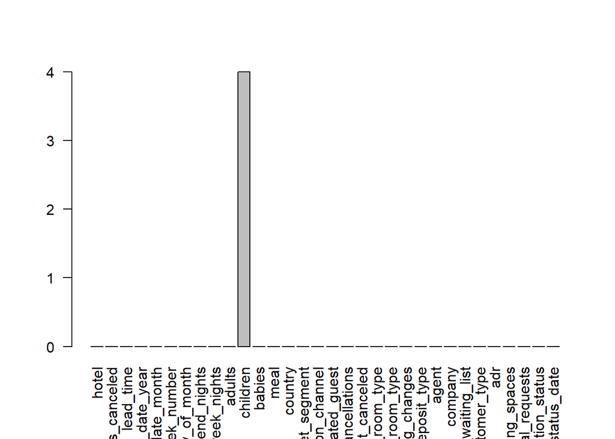

```r
barplot(colSums(is.na(booking)), las=2)
```

Vemos que sólo children tiene Nas (sólo 4). Decidimos que significarán que no había niños en la reserva.

```r
booking[is.na(booking$children),]$children <- 0
```

A continuación, descartamos las variables que creemos que pueden ser no relevantes como datos relacionados con las habitaciones, datos de la agencia, país y algunas de las relacionadas con fechas como puede ser el día del mes.

```r
booking <- booking %>% dplyr::select(-arrival_date_year,
                              -arrival_date_week_number,
                              -arrival_date_day_of_month,
                              -meal,
                              -country,
                              -market_segment,
                              -distribution_channel,
                              -reserved_room_type,
                              -assigned_room_type,
                              -agent,
                              -company,
                              -days_in_waiting_list,
                              -reservation_status,
                              -reservation_status_date)
```

Vemos que variables nos han quedado:

```r
str(booking)
```

```
## 'data.frame':    119390 obs. of  18 variables:
##  $ hotel                         : chr  "Resort Hotel" "Resort Hotel" "Resort Hotel" "Resort Hotel" ...
##  $ is_canceled                   : int  0 0 0 0 0 0 0 0 1 1 ...
##  $ lead_time                     : int  342 737 7 13 14 14 0 9 85 75 ...
##  $ arrival_date_month            : chr  "July" "July" "July" "July" ...
##  $ stays_in_weekend_nights       : int  0 0 0 0 0 0 0 0 0 0 ...
##  $ stays_in_week_nights          : int  0 0 1 1 2 2 2 2 3 3 ...
##  $ adults                        : int  2 2 1 1 2 2 2 2 2 2 ...
##  $ children                      : num  0 0 0 0 0 0 0 0 0 0 ...
##  $ babies                        : int  0 0 0 0 0 0 0 0 0 0 ...
##  $ is_repeated_guest             : int  0 0 0 0 0 0 0 0 0 0 ...
##  $ previous_cancellations        : int  0 0 0 0 0 0 0 0 0 0 ...
##  $ previous_bookings_not_canceled: int  0 0 0 0 0 0 0 0 0 0 ...
##  $ booking_changes               : int  3 4 0 0 0 0 0 0 0 0 ...
##  $ deposit_type                  : chr  "No Deposit" "No Deposit" "No Deposit" "No Deposit" ...
##  $ customer_type                 : chr  "Transient" "Transient" "Transient" "Transient" ...
##  $ adr                           : num  0 0 75 75 98 ...
##  $ required_car_parking_spaces   : int  0 0 0 0 0 0 0 0 0 0 ...
##  $ total_of_special_requests     : int  0 0 0 0 1 1 0 1 1 0 ...
```

Vamos a hacer algunas transformaciones:

- Convertir los meses en estaciones.
- Sumar niños y bebés.
- Sumar todas las noches.
- Hacer que las variable previous_cancellations y previous_bookings_not_canceled sean binaria.

```r
booking <- booking %>%
  mutate(season = ifelse(arrival_date_month %in% c("December", "January", "February"), "Winter",
                  ifelse(arrival_date_month %in% c("March", "April", "May"), "Spring",
                  ifelse(arrival_date_month %in% c("June", "July", "August"), "Summer",
                  "Autumm"))),
         children = children + babies,
         total_nights = stays_in_week_nights + stays_in_weekend_nights,
         previous_cancellations = ifelse(previous_cancellations > 0, 1, 0),
         previous_bookings_not_canceled = ifelse(previous_bookings_not_canceled > 0, 1, 0)) %>%
  dplyr::select(-arrival_date_month, -babies, -stays_in_week_nights, -stays_in_weekend_nights)
```

Hacemos conversiones de tipos de datos a factores en variables categóricas.

```r
booking$hotel <- as.factor(booking$hotel)
booking$is_canceled <- as.factor(booking$is_canceled)
booking$is_repeated_guest <- as.factor(booking$is_repeated_guest)
booking$deposit_type <- as.factor(booking$deposit_type)
booking$customer_type <- as.factor(booking$customer_type)
booking$season <- as.factor(booking$season)
booking$previous_cancellations <- as.factor(booking$previous_cancellations)
booking$previous_bookings_not_canceled <- as.factor(booking$previous_bookings_not_canceled)
```

Ahora, vemos que aspecto tienen nuestras variables, además de cómo se relacionan con la variable target.

```r
str(booking)
```

```
## 'data.frame':    119390 obs. of  16 variables:
##  $ hotel                         : Factor w/ 2 levels "City Hotel","Resort Hotel": 2 2 2 2 2 2 2 2 2 2 ...
##  $ is_canceled                   : Factor w/ 2 levels "0","1": 1 1 1 1 1 1 1 1 2 2 ...
##  $ lead_time                     : int  342 737 7 13 14 14 0 9 85 75 ...
##  $ adults                        : int  2 2 1 1 2 2 2 2 2 2 ...
##  $ children                      : num  0 0 0 0 0 0 0 0 0 0 ...
##  $ is_repeated_guest             : Factor w/ 2 levels "0","1": 1 1 1 1 1 1 1 1 1 1 ...
##  $ previous_cancellations        : Factor w/ 2 levels "0","1": 1 1 1 1 1 1 1 1 1 1 ...
##  $ previous_bookings_not_canceled: Factor w/ 2 levels "0","1": 1 1 1 1 1 1 1 1 1 1 ...
##  $ booking_changes               : int  3 4 0 0 0 0 0 0 0 0 ...
##  $ deposit_type                  : Factor w/ 3 levels "No Deposit","Non Refund",..: 1 1 1 1 1 1 1 1 1 1 ...
##  $ customer_type                 : Factor w/ 4 levels "Contract","Group",..: 3 3 3 3 3 3 3 3 3 3 ...
##  $ adr                           : num  0 0 75 75 98 ...
##  $ required_car_parking_spaces   : int  0 0 0 0 0 0 0 0 0 0 ...
##  $ total_of_special_requests     : int  0 0 0 0 1 1 0 1 1 0 ...
##  $ season                        : Factor w/ 4 levels "Autumm","Spring",..: 3 3 3 3 3 3 3 3 3 3 ...
##  $ total_nights                  : int  0 0 1 1 2 2 2 2 3 3 ...
```

```r
summary(booking)
```

```
##           hotel       is_canceled   lead_time       adults
##  City Hotel  :79330   0:75166     Min.   :  0   Min.   : 0.000
##  Resort Hotel:40060   1:44224     1st Qu.: 18   1st Qu.: 2.000
##                                   Median : 69   Median : 2.000
##                                   Mean   :104   Mean   : 1.856
##                                   3rd Qu.:160   3rd Qu.: 2.000
##                                   Max.   :737   Max.   :55.000
##     children       is_repeated_guest previous_cancellations
##  Min.   : 0.0000   0:115580          0:112906
##  1st Qu.: 0.0000   1:  3810          1:  6484
##  Median : 0.0000
##  Mean   : 0.1118
##  3rd Qu.: 0.0000
##  Max.   :10.0000
##  previous_bookings_not_canceled booking_changes       deposit_type
##  0:115770                       Min.   : 0.0000   No Deposit:104641
##  1:  3620                       1st Qu.: 0.0000   Non Refund: 14587
##                                 Median : 0.0000   Refundable:   162
##                                 Mean   : 0.2211
##                                 3rd Qu.: 0.0000
##                                 Max.   :21.0000
##          customer_type        adr          required_car_parking_spaces
##  Contract       : 4076   Min.   :  -6.38   Min.   :0.00000
##  Group          :  577   1st Qu.:  69.29   1st Qu.:0.00000
##  Transient      :89613   Median :  94.58   Median :0.00000
##  Transient-Party:25124   Mean   : 101.83   Mean   :0.06252
##                          3rd Qu.: 126.00   3rd Qu.:0.00000
##                          Max.   :5400.00   Max.   :8.00000
##  total_of_special_requests    season       total_nights
##  Min.   :0.0000            Autumm:28462   Min.   : 0.000
##  1st Qu.:0.0000            Spring:32674   1st Qu.: 2.000
##  Median :0.0000            Summer:37477   Median : 3.000
##  Mean   :0.5714            Winter:20777   Mean   : 3.428
##  3rd Qu.:1.0000                           3rd Qu.: 4.000
##  Max.   :5.0000                           Max.   :69.000
```

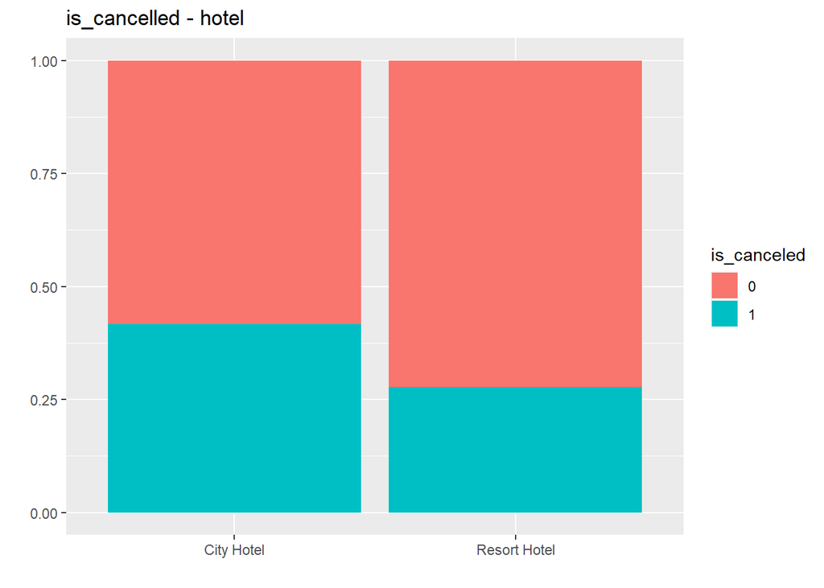

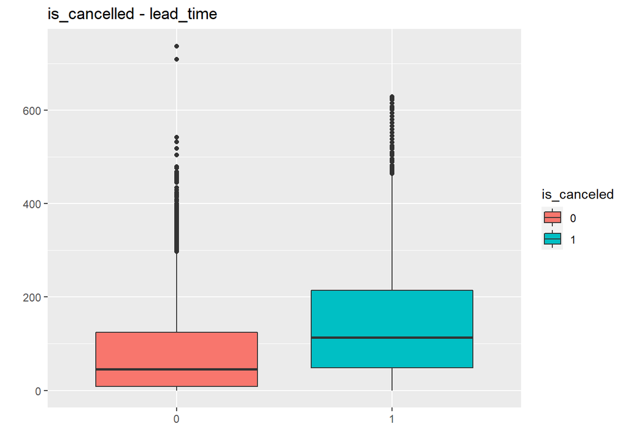

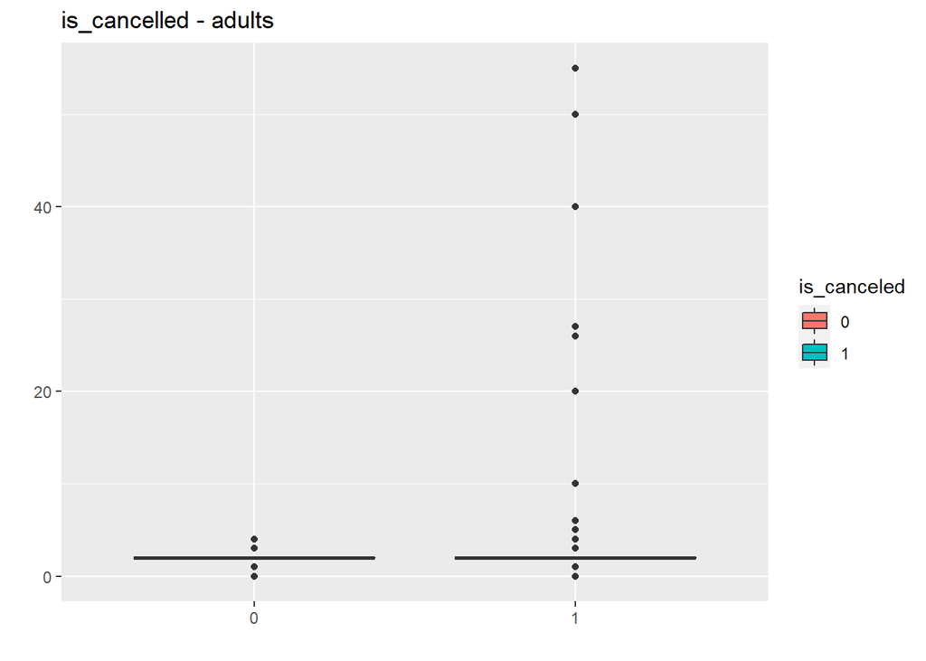

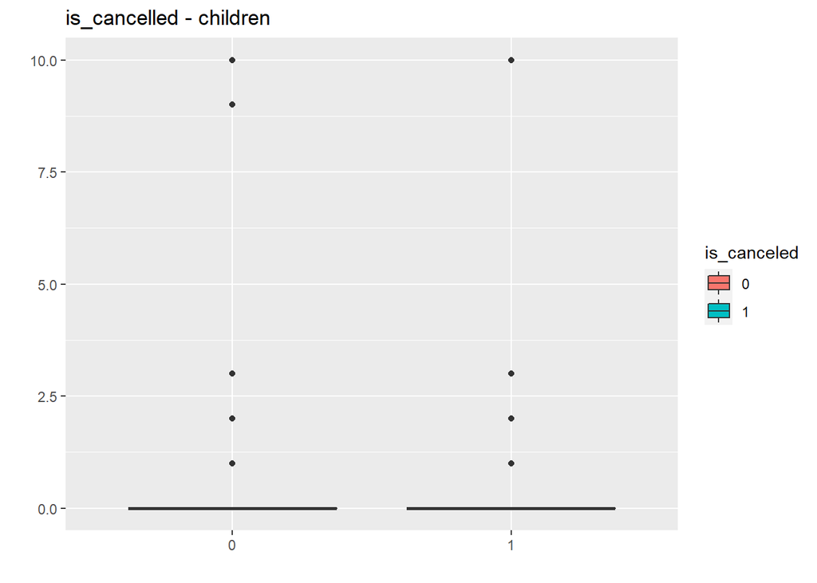

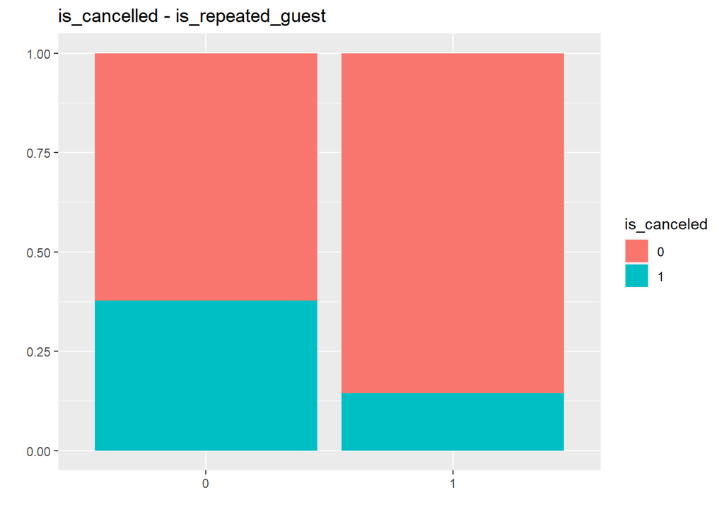

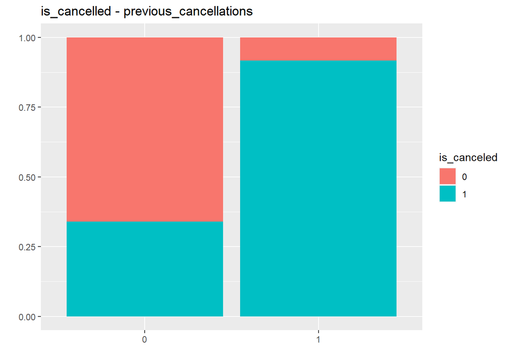

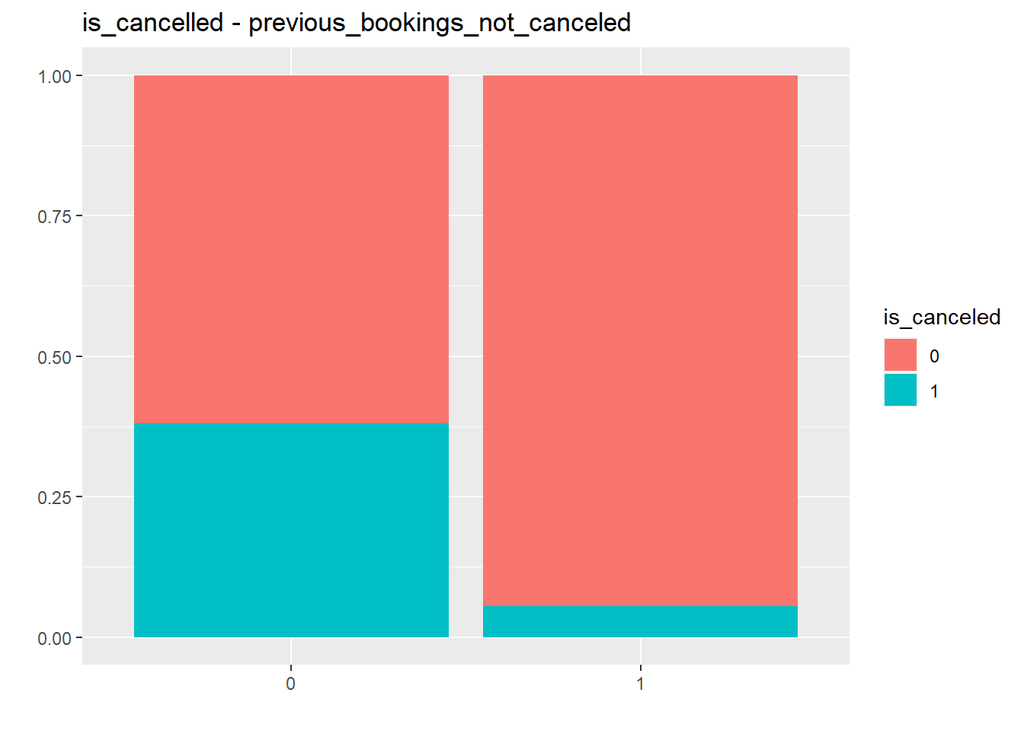

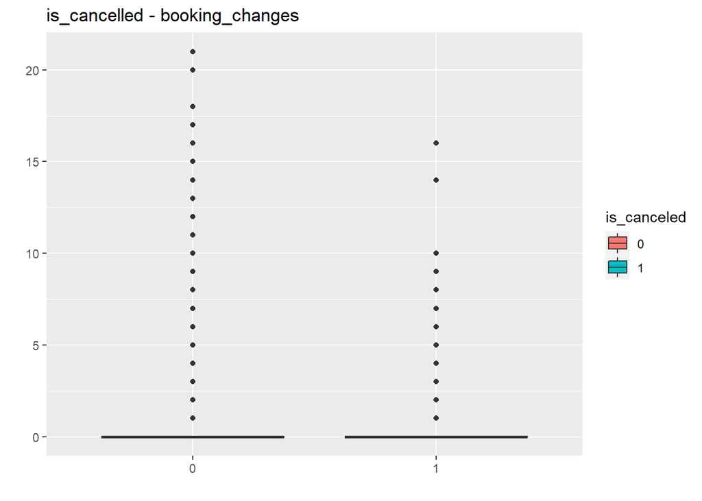

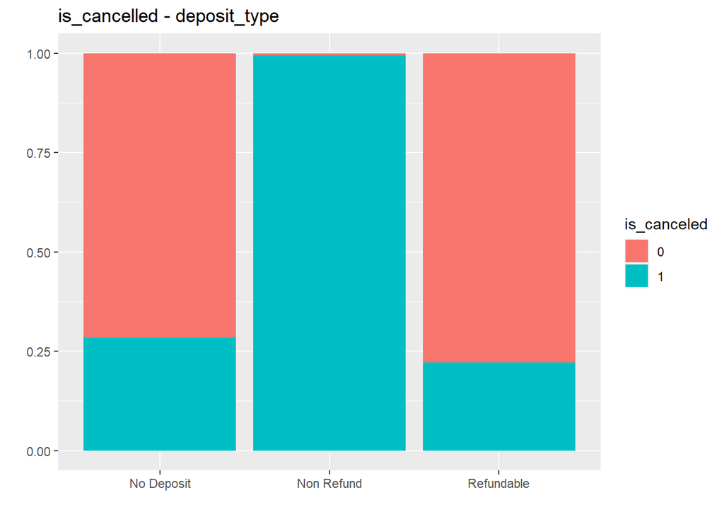

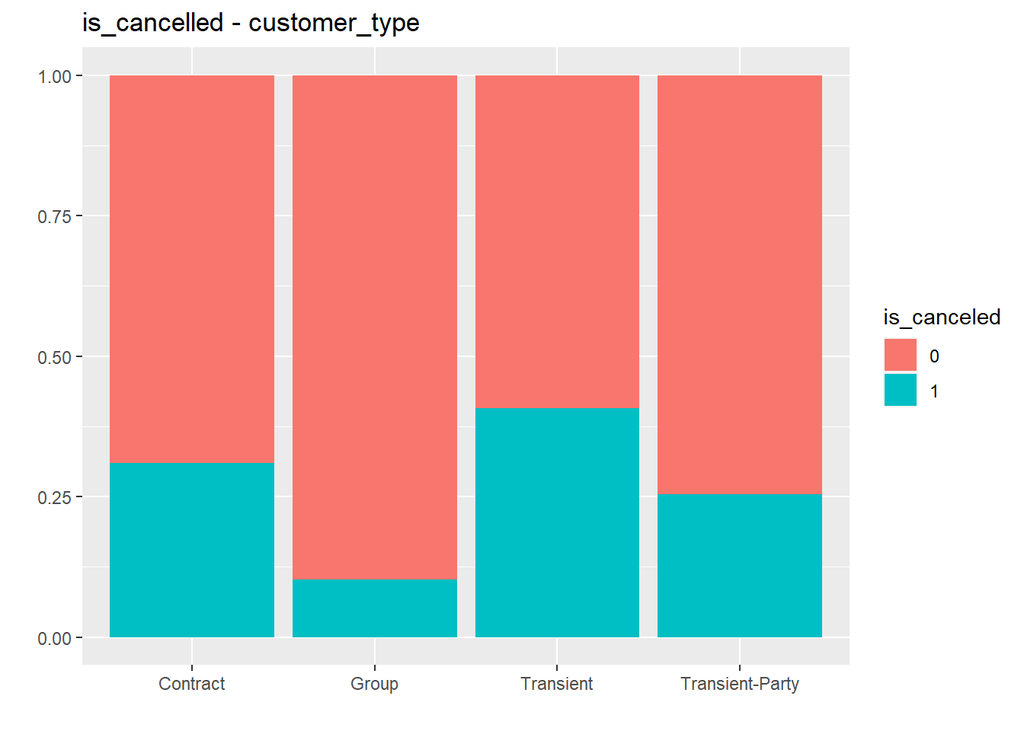

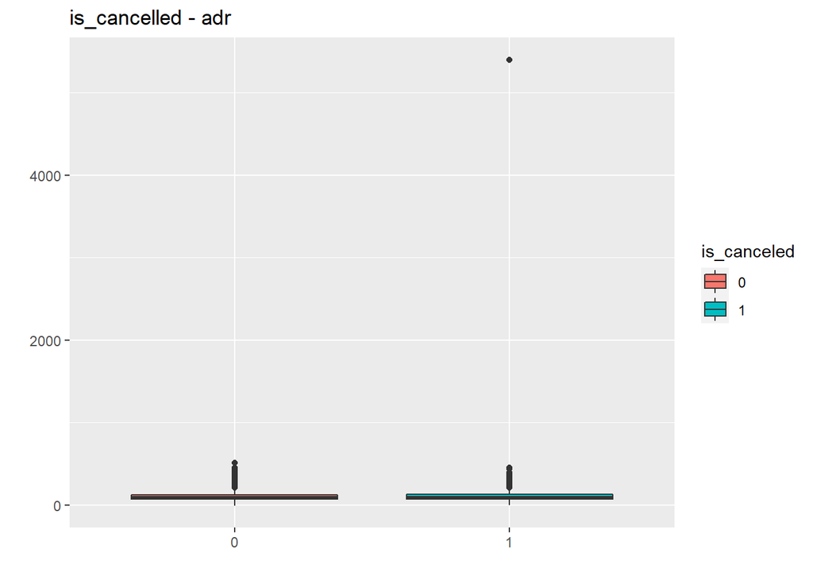

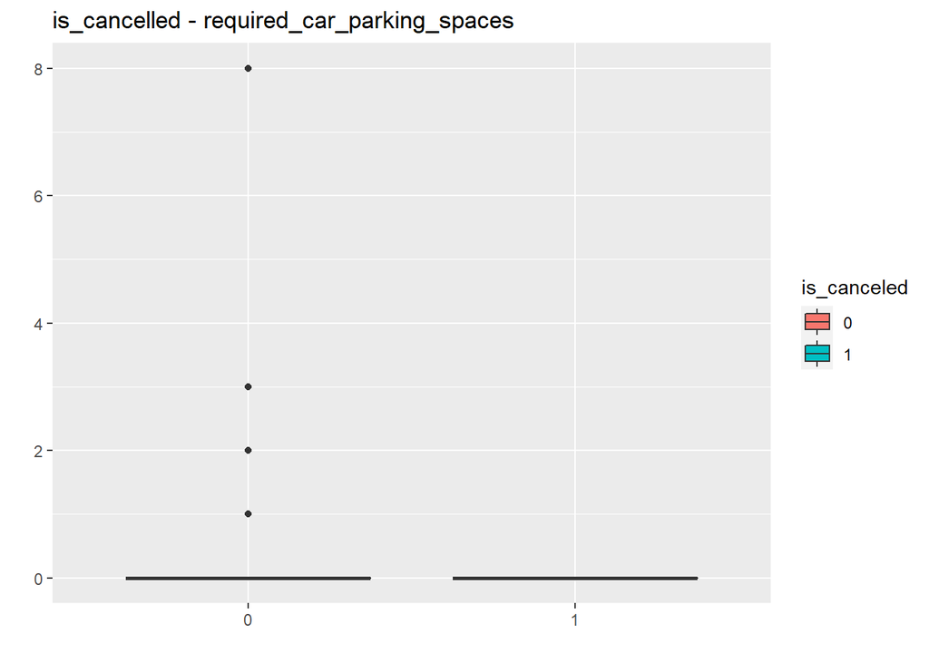

[3 more figures not shown]

```r
numeric_columns_names <- unlist(lapply(booking, is.numeric))
numeric_columns_names <- names(which(numeric_columns_names))

for(i in 1:ncol(booking)){
  if(colnames(booking)[i] != "is_canceled"){
    if (colnames(booking)[i] %in% numeric_columns_names){
      print(booking %>%
        ggplot(aes(x= is_canceled, y = booking[,i], fill = is_canceled)) + geom_boxplot() +
        labs(title = paste("is_cancelled -", names(booking)[i]), x = "", y = "", col = ""))
    }else{
      print(booking %>%
        ggplot(aes(x= booking[,i], fill = is_canceled)) + geom_bar(position = "fill") +
        labs(title = paste("is_cancelled -", names(booking)[i]), x = "", y = "", col = ""))
    }
  }
}
```

Podemos sacar ciertas conclusiones de estas gráficas:

- En los hoteles de Ciudad la gente cancela con más frecuencia.
- La gente que cancela suele reservar con mayor antelación a la fecha de entrada.
- Suelen ser reservas de pocos adultos, aunque hay algún grupo grande, y casi ningún niño.
- Los clientes que repiten suelen cancelar menos.
- Los clientes que ya han cancelado con anterioridad suelen volver a cancelar.
- Los clientes que han tenido reservas y no las han cancelado no suelen cancelar.
- No es habitual cambios en las reservas.
- Por tipo de cliente, los que menos cancelan son los de Group y los que más los Transient.
- Hay pocas peticiones de parking y, si las hay, nunca cancelan la reserva.
- Normalmente, si tienes peticiones especiales, no cancelas.
- Por estaciones del año, las cancelaciones no tienen mucha varianza.
- En cuanto a noches, no se aprecia diferencia entre la gente que cancela y que no.

Algo a destacar es que hay reservas sin adultos. Podemos pensar que a lo mejor son reservas de adolescentes que son dados como niños y que podría existir este tipo de dato. Sin embargo, podemos ver que existen reservas en las que no hay ni adultos ni niños y, que por lo tanto, deben ser errores, así que procedemos a eliminarlas.

```r
nrow(booking[((booking$adults == 0) & (booking$children == 0)),])
```

```
## [1] 180
```

```r
booking <- booking[!((booking$adults == 0) & (booking$children == 0)),]
```

Algo extraño sucede con la columna que indica el tipo de depósito, deposit_type:‘Non Refund’, y ‘is_canceled’ están correlacionadas de manera contraria a la intuición. Más del 99 % de las personas que pagaron el monto total de la reserva por adelantado cancelaron. Todo parece indicar que es un error de los datos, así que vamos a desestimar esta columna.

```r
table(booking$deposit_type, booking$is_canceled)
```

```
##
##                  0     1
##   No Deposit 74792 29669
##   Non Refund    93 14494
##   Refundable   126    36
```

```r
booking <- booking %>% dplyr::select(-deposit_type)
```

Hemos visto que en la columna adr parece que hay un outlier muy claro pues tiene un valor mayor que 5000 cuando la media está en unos 100. Además, vemos que también parece que existen valores negativos, lo cual es imposible. Vemos que estas anomalías corresponden a únicamente dos filas, las cuales eliminamos.

```r
booking[(booking$adr>5000 | booking$adr < 0),]
```

```
##              hotel is_canceled lead_time adults children is_repeated_guest
## 14970 Resort Hotel           0       195      2        0                 1
## 48516   City Hotel           1        35      2        0                 0
##       previous_cancellations previous_bookings_not_canceled booking_changes
## 14970                      0                              1               2
## 48516                      0                              0               1
##         customer_type     adr required_car_parking_spaces
## 14970 Transient-Party   -6.38                           0
## 48516       Transient 5400.00                           0
##       total_of_special_requests season total_nights
## 14970                         0 Spring           10
## 48516                         0 Spring            1
```

```r
booking <- booking[!(booking$adr>5000 | booking$adr < 0),]
```

Ahora podemos ver más claramente la relación de adr con el Target y vemos que no parece que haya gran diferencia de precios entre reservas canceladas y sin cancelar.

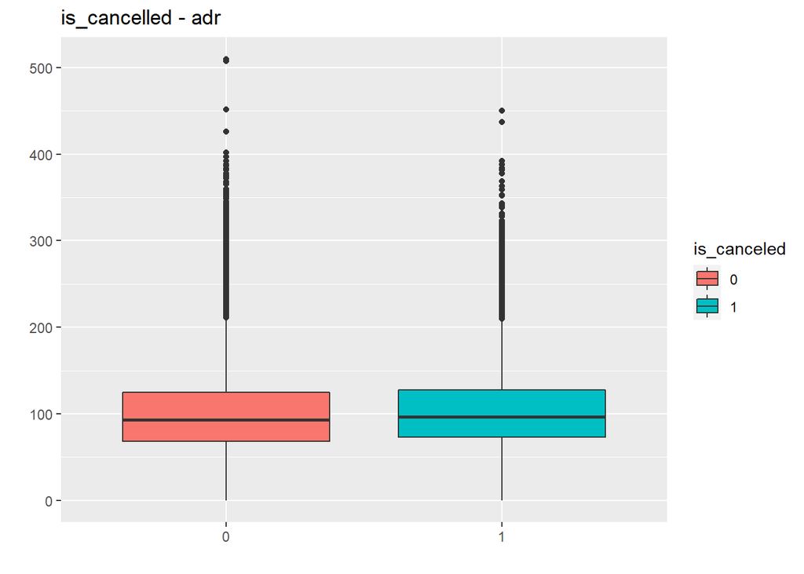

```r
booking %>%
  ggplot(aes(x= is_canceled, y = adr, fill = is_canceled)) + geom_boxplot() +
  labs(title = "is_cancelled - adr", x = "", y = "", col = "")
```

Mostramos las correlaciones de las variables númericas y vemos que no hay ninguna significativa.

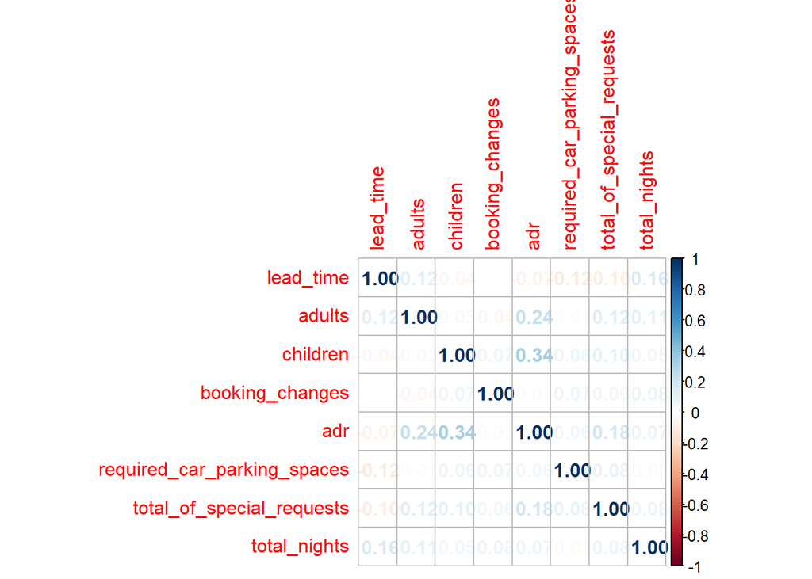

```r
numeric_columns <- unlist(lapply(booking, is.numeric))
numeric_columns <- booking[, numeric_columns]

corrplot(cor(numeric_columns), method='number')
```

La última relación que queremos ver antes de empezar a realizar modelos es la que puede existir entre número de personas y el tipo de cliente. Vemos que las reservas con muchas personas suelen pertener al tipo Group pero, sin embargo, las reservas de todos los tipos de cliente se centran en 2-3 personas.

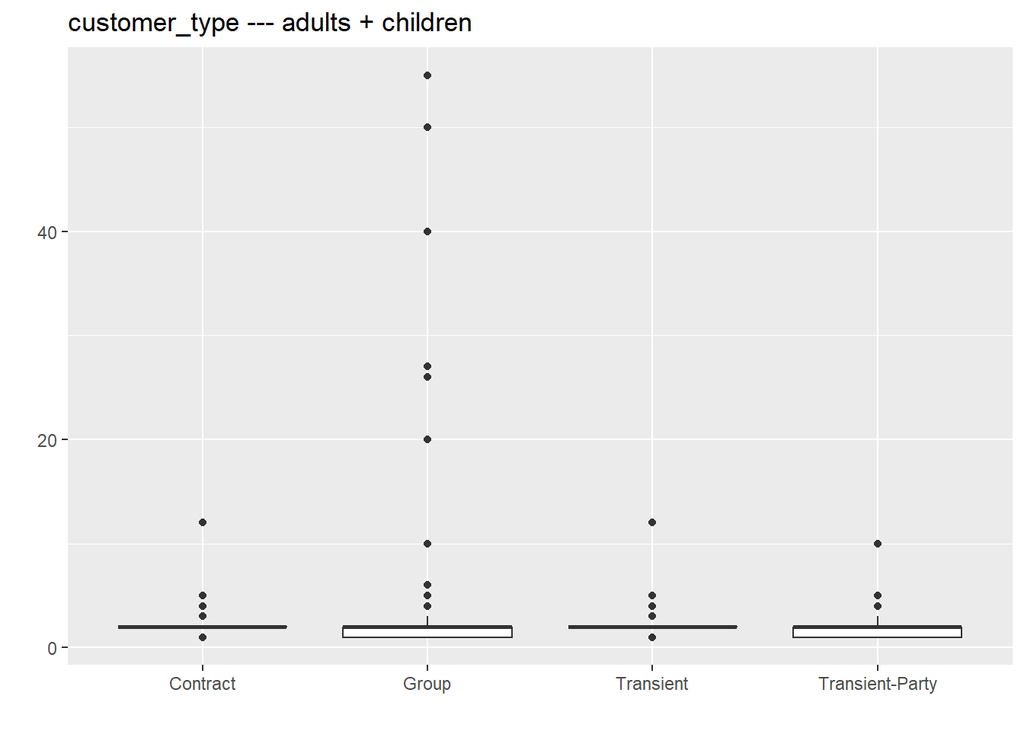

```r
booking %>%
  ggplot(aes(x= customer_type, y = adults + children)) + geom_boxplot() +
  labs(title = "customer_type --- adults + children", x = "", y = "", col = "")
```

## GLM

Para empezar crearemos una partición de nuestros datos para train y test y elaboraremos un modelo con todas las variables.

```r
partition <- sort(sample(nrow(booking), nrow(booking)*.7))

booking.train <- booking[partition,]
booking.test <- booking[-partition,]

mod_general <- glm(is_canceled ~ ., family=binomial(link="logit"), data=booking.train)

summary(mod_general)
```

```
##
## Call:
## glm(formula = is_canceled ~ ., family = binomial(link = "logit"),
##     data = booking.train)
##
## Deviance Residuals:
##     Min       1Q   Median       3Q      Max
## -3.1445  -0.8457  -0.4029   0.8849   4.2084
##
## Coefficients:
##                                   Estimate Std. Error z value Pr(>|z|)
## (Intercept)                     -2.775e+00  7.936e-02 -34.967  < 2e-16 ***
## hotelResort Hotel               -1.731e-01  1.981e-02  -8.738  < 2e-16 ***
## lead_time                        6.406e-03  9.752e-05  65.697  < 2e-16 ***
## adults                           1.313e-02  1.390e-02   0.944  0.34509
## children                        -2.497e-02  2.225e-02  -1.122  0.26170
## is_repeated_guest1              -1.147e+00  1.505e-01  -7.622 2.50e-14 ***
## previous_cancellations1          5.077e+00  1.374e-01  36.949  < 2e-16 ***
## previous_bookings_not_canceled1 -3.506e+00  1.894e-01 -18.513  < 2e-16 ***
## booking_changes                 -5.308e-01  1.876e-02 -28.299  < 2e-16 ***
## customer_typeGroup               2.825e-01  2.071e-01   1.364  0.17251
## customer_typeTransient           1.680e+00  6.998e-02  24.000  < 2e-16 ***
## customer_typeTransient-Party     2.229e-01  7.261e-02   3.070  0.00214 **
## adr                              6.567e-03  2.283e-04  28.764  < 2e-16 ***
## required_car_parking_spaces     -1.659e+01  4.807e+01  -0.345  0.73002
## total_of_special_requests       -7.911e-01  1.275e-02 -62.075  < 2e-16 ***
## seasonSpring                     1.833e-01  2.444e-02   7.499 6.42e-14 ***
## seasonSummer                    -1.849e-01  2.526e-02  -7.317 2.53e-13 ***
## seasonWinter                     2.901e-01  2.916e-02   9.948  < 2e-16 ***
## total_nights                     6.084e-03  3.631e-03   1.676  0.09380 .
## ---
## Signif. codes:  0 '***' 0.001 '**' 0.01 '*' 0.05 '.' 0.1 ' ' 1
##
## (Dispersion parameter for binomial family taken to be 1)
##
##     Null deviance: 110183  on 83444  degrees of freedom
## Residual deviance:  80991  on 83426  degrees of freedom
## AIC: 81029
##
## Number of Fisher Scoring iterations: 16
```

Para obtener una medida de la variabilidad explicada por el modelo, hemos de comparar la devianza del modelo nulo (Null deviance) con la devianza residual (Residual deviance), esto es, una medida de cuánto de la variabilidad de la variable Target es explicado por el modelo:
$$D^2 = (1- \frac{Residual.deviance}{Null.deviance}) * 100$$

De modo que obtenemos $D^2 = 26.49$, es decir, no llegamos a explicar ni a un 30% de la devianza.

Además, el AIC que obtenemos es igual a 81029.

Podemos hacer predicciones con este modelo con la partición que hemos creado para test:

```r
mod_general.prob <- predict(mod_general, newdata = booking.test, type = "response")
mod_general.pred <- ifelse(mod_general.prob > 0.5, 1, 0)
confusionMatrix(table(prediction=mod_general.pred, reference=booking.test$is_canceled))
```

```
## Confusion Matrix and Statistics
##
##           reference
## prediction     0     1
##          0 19953  5416
##          1  2686  7708
##
##                Accuracy : 0.7735
##                  95% CI : (0.7691, 0.7778)
##     No Information Rate : 0.633
##     P-Value [Acc > NIR] : < 2.2e-16
##
##                   Kappa : 0.4901
##
##  Mcnemar's Test P-Value : < 2.2e-16
##
##             Sensitivity : 0.8814
##             Specificity : 0.5873
##          Pos Pred Value : 0.7865
##          Neg Pred Value : 0.7416
##              Prevalence : 0.6330
##          Detection Rate : 0.5579
##    Detection Prevalence : 0.7094
##       Balanced Accuracy : 0.7343
##
##        'Positive' Class : 0
##
```

Ahora probaremos a crear un modelo según nuestra intuición.

Para ello, usaremos las siguientes variables e interacciones:

- **lead_time**: el tiempo con el que se reserva una habitación puede ser significante. Se podría dar el caso de que, por ejemplo, un cliente reserva con demasiada antelación y por el camino surgen imprevistos que le obligan a cancelar la reserva.
- **customer_type**: puede ser que a tipos de clientes como los Grupos les fallen personas para un viaje pero, aún así, sigan manteniendo una reserva.
- **total_nights**: En viajes largos cabe la posibilidad de que existan más imprevistos que en escapadas de un par de días o que, por el contrario, como necesitan más preparación, menos frecuente sea su cancelación.
- **lead_time:customer_type**: a lo mejor el tipo de cliente y el tiempo de antelación están relacionados. Ejemplo: un grupo puede necesitar más tiempo para reservar que a lo mejor un cliente de paso.
- **leadtime:total_nights**: para viajes largos, normalmente, debes reservar con más tiempo para no quedarse uno sin hueco o no enfrentarse a una subida de precios.
- **lead_time:season**: en estaciones con mayor demanda es necesario reservar con mayor antelación.
- **adults**: cuantos más adultos más posibilidades de cancelarlo por imprevistos.
- **adr**: a lo mejor a mayor gasto, mayor posibilidad de que se cancele una reserva por dificultades económicas.
- **adr:adults**: a lo mejor viajes organizados, donde suelen ir grupos más grandes de adultos y que acaban siendo más caros, pueden ser más difícil de cancelar.
- **is_repeated_guest**: gente con más reservas en hoteles y más viajes hechos pueden estar más acostumbrados a organizarlos y no tener que cancelarlos.
- **previous_cancellations**: personas que ya han tenido reserva canceladas pueden volver a cancelar otra vez.
- **booking_changes** y **total_of_special_requests**: hacer cambios y peticiones especiales puede significar que uno está más comprometido con un viaje y puede ser más inusual que lo cancele al mostrar tanto interés.

Con estas variables e interacciones calculamos un modelo:

```r
mod_manual <- glm(is_canceled ~
               lead_time * (customer_type + total_nights)
               + lead_time:season
               + adr * adults
               + is_repeated_guest * previous_cancellations
               + booking_changes
               + total_of_special_requests
             ,
             family=binomial(link="logit"), data=booking.train)
summary(mod_manual)
```

```
##
## Call:
## glm(formula = is_canceled ~ lead_time * (customer_type + total_nights) +
##     lead_time:season + adr * adults + is_repeated_guest * previous_cancellations +
##     booking_changes + total_of_special_requests, family = binomial(link = "logit"),
##     data = booking.train)
##
## Deviance Residuals:
##     Min       1Q   Median       3Q      Max
## -3.1981  -0.7858  -0.4961   0.8314   4.3550
##
## Coefficients:
##                                              Estimate Std. Error z value
## (Intercept)                                -3.224e+00  1.341e-01 -24.041
## lead_time                                   7.450e-03  7.247e-04  10.280
## customer_typeGroup                         -6.166e-01  2.876e-01  -2.144
## customer_typeTransient                      8.673e-01  1.048e-01   8.279
## customer_typeTransient-Party                6.502e-01  1.085e-01   5.990
## total_nights                                7.962e-02  5.469e-03  14.558
## adr                                         1.322e-02  6.959e-04  19.000
## adults                                      3.592e-01  4.229e-02   8.495
## is_repeated_guest1                         -1.812e+00  1.288e-01 -14.065
## previous_cancellations1                     5.232e+00  1.458e-01  35.894
## booking_changes                            -5.792e-01  1.871e-02 -30.964
## total_of_special_requests                  -8.120e-01  1.286e-02 -63.159
## lead_time:customer_typeGroup                2.848e-04  1.894e-03   0.150
## lead_time:customer_typeTransient            5.258e-03  6.877e-04   7.646
## lead_time:customer_typeTransient-Party     -4.248e-03  7.062e-04  -6.015
## lead_time:total_nights                     -8.444e-04  3.933e-05 -21.471
## lead_time:seasonSpring                      1.662e-03  1.883e-04   8.830
## lead_time:seasonSummer                     -1.560e-03  1.712e-04  -9.114
## lead_time:seasonWinter                      4.831e-03  3.145e-04  15.360
## adr:adults                                 -3.653e-03  3.371e-04 -10.838
## is_repeated_guest1:previous_cancellations1 -1.910e+00  2.110e-01  -9.050
##                                            Pr(>|z|)
## (Intercept)                                 < 2e-16 ***
## lead_time                                   < 2e-16 ***
## customer_typeGroup                           0.0321 *
## customer_typeTransient                      < 2e-16 ***
## customer_typeTransient-Party               2.09e-09 ***
```

[output cut: 11 more lines]

```
## lead_time:seasonSpring                      < 2e-16 ***
## lead_time:seasonSummer                      < 2e-16 ***
## lead_time:seasonWinter                      < 2e-16 ***
## adr:adults                                  < 2e-16 ***
## is_repeated_guest1:previous_cancellations1  < 2e-16 ***
## ---
## Signif. codes:  0 '***' 0.001 '**' 0.01 '*' 0.05 '.' 0.1 ' ' 1
##
## (Dispersion parameter for binomial family taken to be 1)
##
##     Null deviance: 110183  on 83444  degrees of freedom
## Residual deviance:  82337  on 83424  degrees of freedom
## AIC: 82379
##
## Number of Fisher Scoring iterations: 7
```

Parece que ahora tenemos una devianza algo peor que en el anterior modelo, aunque por poco. Igual nos ocurre con el AIC, parecidos pero, ahora algo peor.

Ahora veamos las gráficas para interpretar el modelo.

```r
plot(allEffects(mod_manual), ci.style="band", rescale.axis=FALSE, multiline=TRUE, ylab="P(released)", rug=FALSE, main="")
```

[figure not shown]

```r
table(booking$customer_type)
```

```
##
##        Contract           Group       Transient Transient-Party
##            4072             574           89475           25087
```

Ahora procedemos a hacer una predicción a ver si en ello también ha empeorado nuestro modelo:

```r
mod_manual.prob <- predict(mod_manual, newdata = booking.test, type = "response")
mod_manual.pred <- ifelse(mod_manual.prob > 0.5, 1, 0)
confusionMatrix(table(prediction=mod_manual.pred, reference=booking.test$is_canceled))
```

```
## Confusion Matrix and Statistics
##
##           reference
## prediction     0     1
##          0 20130  5963
##          1  2509  7161
##
##                Accuracy : 0.7631
##                  95% CI : (0.7587, 0.7675)
##     No Information Rate : 0.633
##     P-Value [Acc > NIR] : < 2.2e-16
##
##                   Kappa : 0.4603
##
##  Mcnemar's Test P-Value : < 2.2e-16
##
##             Sensitivity : 0.8892
##             Specificity : 0.5456
##          Pos Pred Value : 0.7715
##          Neg Pred Value : 0.7405
##              Prevalence : 0.6330
##          Detection Rate : 0.5629
##    Detection Prevalence : 0.7296
##       Balanced Accuracy : 0.7174
##
##        'Positive' Class : 0
##
```

En cuanto a predicciones, también tenemos menos accuracy que el modelo que usaba todas las predicciones sin ionteracciones.